# Virginia Math Bulletin 2019 — UVA Mathematics

## In Memoriam: Nathaniel Martin

By Tom Kriete Nathaniel F. G. Martin, Professor Emeritus of Mathematics, passed away peacefully at home on February 28. He is survived by his wife of sixty-four years Jo Martin, his sons Nathaniel and Jon and their wives, and four grandchildren. He was a long-time active member of Westminster Presbyterian Church. Nat was born in Wichita Falls, Texas, on October 10, 1928. He attended Harden Junior College and North Texas University where he received BS and MS degrees. During the Korean War he served in the Navy and was stationed in Washington D.C. at the National Security Agency. Nat’s maritime interests began early; he and his father built his first boat during World War II and he remained a life-long sailor. After leaving the Navy, he attended Iowa State University where he earned a Ph.D. in Mathematics in 1959. He joined the faculty at the University of Virginia that year and remained until his retirement as full professor in 1997. Nat’s research interests were in real analysis and ergodic theory.

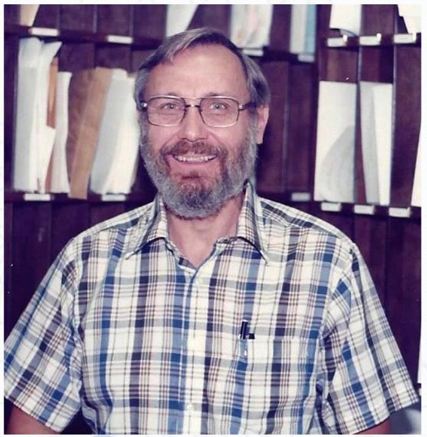

He was the author of a number of papers on those subjects, and co-author with James England of Mathematical Theory of Entropy, published in 1981 as Volume 12 of the Encyclopedia of Mathematics and Its Applications. His later work employed complex-analytic methods to study the ergodic properties of inner functions. Nat and his family enjoyed travel, and they spent sabbatical years at the University of California at Berkeley, the University of Copenhagen, and University College, London. He served as Associate Dean of the Graduate School of Arts and Sciences, and Associate Chair of the Department of Mathematics. Nat was an excellent and even inspiring teacher, known especially for his courses in real analysis. His collegial nature and good humor were uniformly appreciated by his colleagues and students. He will be missed by those who knew him.

## The Problem Corner

1. Find the largest possible positive constant $C$ such that for all real numbers $x, y$ we have that $C(|x|+|y|) \leq \max (|x|,|x+y|)$.
2. Let $\mathbb{Z}_{2n}$ be the integers modulo $2n$, i.e., the set of numbers $\{0,1,2, \ldots, 2n-1\}$, where we add and subtract modulo $2n$. Let $S \subseteq \mathbb{Z}_{2n}$ having cardinality $n$. Let $T$ be the complement of $S$ in $\mathbb{Z}_{2n}$. Prove that the set of numbers $S-S$ is equal to the set of numbers $T-T$ in $\mathbb{Z}_{2n}$. Here, $S-S=\{a-b \mid a, b \in S\}$.
3. Let $s_{1}, \ldots, s_{n}$ be positive numbers, and let $s$ be their sum. Prove that
   $$\left(1+s_{1}\right)\left(1+s_{2}\right) \ldots\left(1+s_{n}\right)<1+s+s^{2} / 2!+\ldots+s^{n} / n!$$
4. Let $\left(a_{1}, b_{1}\right), \ldots,\left(a_{n}, b_{n}\right)$ be pairs of integers such that $a_{i}$ and $b_{i}$ are relatively prime for all $i=1, \ldots, n$. Prove there is a homogeneous polynomial $f(x, y)$ in two variables such that $f\left(a_{i}, b_{i}\right)=1$ for all $i=1, \ldots, n$.

   (This problem has a particularly UVa history. It came up in a research project, and was solved by a then graduate student, John Berman. He suggested it for the International Math Olympiad (IMO), and it appeared as a problem in the 2017 IMO. It was completely solved by just 14 students, making it one of the most challenging problems to appear on that years exam!)

What are you doing? We’d love to hear from you!

Email: math-newsletter@virginia.edu  
News & Events: http://math.virginia.edu/allnews/

Department of Mathematics  
University of Virginia  
P. O. Box 400137

Charlottesville, VA 22904-4137